# Actividad 11

Como bien se conoce, el objetivo principal que tiene cada equipo es lograr anotar goles, y es por esto que los entrenadores se esfuerzan al máximo por encontrar las mejores estrategias para lograr marcar un gol. Estas suelen ser rápidas, con mucha posesión de balón o incluso jugando lento, con el fin de ir encontrando los espacios para llegar al área rival. El momento más importante de la jugada se da cuando ya esté a punto de terminar, o sea, cuando se está llegando al arco rival y los jugadores tienen la oportunidad de chutear el balón, sin embargo, el gol no siempre llega y es por esto que en la siguiente figura deseamos analizar en qué terminan cada una de estas oportunidades filtrando por liga.

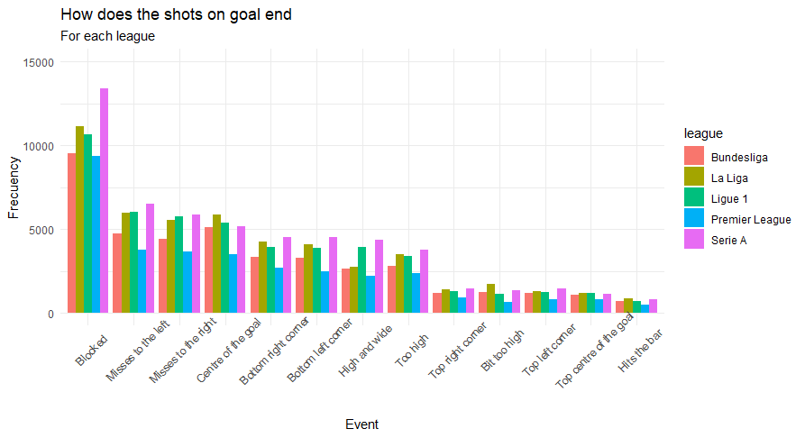

En primer lugar vemos que los eventos que más ocurren van de izquierda a derecha. Luego, en términos generales podemos observar que de todos los disparos a puerta la gran mayoría terminan siendo disparos bloqueados (tapados por el arquero o por algún jugador) y algo a destacar es que aquellos disparos pueden haber ido directamente a portería o pueden haber ido hacia afuera. Por otro lado, los eventos que vienen no fueron bloqueados por ningún jugador, sino que, fue el resultado final de cómo fue el tiro. Podemos observar que, en las 5 ligas, cuando más fallan es cuando disparan hacia los lados de la portería y, luego de eso el tiro con mayor probabilidad de caer dentro del arco es cuando intentan disparar hacia el centro del mismo.